# Shoe vs Sandal vs Boot

> [Data Source can be found here](https://www.kaggle.com/datasets/hasibalmuzdadid/shoe-vs-sandal-vs-boot-dataset-15k-images)

The dataset contains 15,000 images of shoes, sandals, and boots for classification problems. Each type contains a shoe, sandal, or a boot.

## Exploring the Data

First off, we explore the dataset before performing data science techniques. Learning about the data can help us see what problems might come up before we train our first model.

The code below takes three random images from each folder and shows it to us.

First, let us set the `RANDOM_SEED` so that our results are reproducible.

```python
RANDOM_SEED = 10
```

After doing so, we will set `DATA_PATH` to the location of our data files. Just extract everything in the folder into `data` and do not do any processing as the notebook will do that.

```python
from pathlib import Path

DATA_PATH = Path("data")
```

The locations of each image file is listed below. 3 random images from each category is chosen and shown on the next section.

```python
boots = list(DATA_PATH.glob("Boot/*.jpg"))
sandals = list(DATA_PATH.glob("Sandal/*.jpg"))
shoes = list(DATA_PATH.glob("Shoe/*.jpg"))
```

```python
import random

random.seed(RANDOM_SEED)
random_images = [
    *random.sample(boots, k=3),
    *random.sample(sandals, k=3),
    *random.sample(shoes, k=3),
]
random_images[:3]
```

```
[WindowsPath('data/Boot/boot (710).jpg'),
 WindowsPath('data/Boot/boot (1238).jpg'),
 WindowsPath('data/Boot/boot (4160).jpg')]
```

[figure not shown]

```python
from PIL import Image
import matplotlib.pyplot as plt

fig = plt.figure(figsize=(8, 5))

for index, image in enumerate(random_images):
    current = Image.open(image)
    label = image.parent.stem

    plt.subplot(3, 3, index + 1)
    plt.imshow(current)
    plt.title(label)
    plt.axis(False)
```

From the above, it is clear to me what the differences between a boot, a sandal, and a shoe are. The boot has a higher shaft than the other two while sandals are the most open among all. I think that a machine learning model can definitely do this.

## Splitting the Data into Train and Test

Because there are 15,000 samples of training and testing, I will split the data into the following:

- 80% Training
- 15% Validation
- 5% Testing

In absolute terms, there will be 12000 training samples, 2250 validation samples, and 750 testing samples. These will be split equally among the data.

First, we import the modules we'll need and set the device we're going to use.

```python
import torch
import torchvision
import torchvision.transforms as transforms
```

```python
device = "cuda" if torch.cuda.is_available() else "cpu"
device
```

```
'cuda'
```

To make things consistent, we must create a series of transforms for our data to work on. First, we resize the images to a 64 pixel height and 64 pixel width. Finally, we convert the image into a tensor for use by our neural network.

```python
transforms = transforms.Compose([
    transforms.Resize((64, 64)),
    transforms.ToTensor(),
])
transforms
```

```
Compose(
    Resize(size=(64, 64), interpolation=bilinear, max_size=None, antialias=None)
    ToTensor()
)
```

Next, we need to get all the data in the `data` folder using `ImageFolder`. This is pretty simple now since `torchvision` will take care of the details for us.

```python
all_data = torchvision.datasets.ImageFolder(
    root=DATA_PATH,
    transform=transforms,
    target_transform=None,
)
all_data
```

```
Dataset ImageFolder
    Number of datapoints: 15000
    Root location: data
    StandardTransform
Transform: Compose(
               Resize(size=(64, 64), interpolation=bilinear, max_size=None, antialias=None)
               ToTensor()
           )
```

```python
all_data.class_to_idx
```

```
{'Boot': 0, 'Sandal': 1, 'Shoe': 2}
```

Due to the way the data is distributed, the 0th, 5000th, and 10000th index will show the Boot, Sandal, and the Shoe.

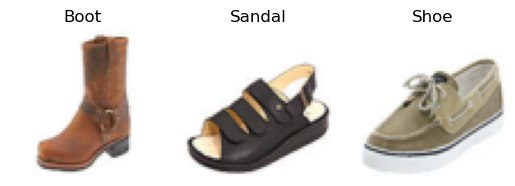

```python
indexes = [0, 5000, 10000]

for i, data_index in enumerate(indexes):
    image, label = all_data[data_index]
    label = all_data.classes[label]

    plt.subplot(1, 3, i + 1)
    plt.imshow(image.permute((1, 2, 0)))
    plt.title(label)
    plt.axis(False)
```

We should now split each dataset into training, validation, and testing. This will consist of two phases:

1. Splitting the original dataset into training and testing. This will be an 80-20 split.
2. Splitting the testing subset into validation and testing. Since the ratio is 5-15, this will be akin to a 25-75 split.

```python
# For reference, these are the indices of each dataset.
# Our goal is to split each equally for the Subset
# [0:5000] -> Boot
# [5000:10000] -> Sandal
# [10000:15000] -> Shoe

# SIZES
train_size = 0.8 * len(all_data) / 3
validation_size = 0.15 * len(all_data) / 3
test_size = 0.05 * len(all_data) / 3

train_size = round(train_size)
validation_size = round(validation_size)
test_size = round(test_size)

# RANGES
boot_range = range(0, 5000)
sandal_range = range(5000, 10000)
shoe_range = range(10000, 15000)
```

```python
from sklearn.model_selection import train_test_split

# Get Training Indices
x_boot_train, x_boot_test, _boot_train, _boot_test = train_test_split(
    boot_range, range(0, 5000),
    shuffle=True,
    test_size=0.2,
    random_state=RANDOM_SEED,
)

x_sandal_train, x_sandal_test, _sandal_train, _sandal_test = train_test_split(
    sandal_range, range(0, 5000),
    shuffle=True,
    test_size=0.2,
    random_state=RANDOM_SEED,
)

x_shoe_train, x_shoe_test, _shoe_train, _shoe_test = train_test_split(
    shoe_range, range(0, 5000),
    shuffle=True,
    test_size=0.2,
    random_state=RANDOM_SEED,
)

train_indices = [
    *x_boot_train,
    *x_sandal_train,
    *x_shoe_train,
]

# Get Validation and Test
# Note: 15-5 split. In other words, a 75-25 split
x_boot_validation, x_boot_test, _boot_validation, _boot_test = train_test_split(
    x_boot_test, range(len(x_boot_test)),
    shuffle=True,
    test_size=0.25,
    random_state=RANDOM_SEED,
)

x_sandal_validation, x_sandal_test, _sandal_validation, _sandal_test = train_test_split(
    x_sandal_test, range(len(x_sandal_test)),
    shuffle=True,
    test_size=0.25,
    random_state=RANDOM_SEED,
)

x_shoe_validation, x_shoe_test, _shoe_validation, _shoe_test = train_test_split(
    x_shoe_test, range(len(x_shoe_test)),
    shuffle=True,
    test_size=0.25,
    random_state=RANDOM_SEED,
)

validation_indices = [
    *x_boot_validation,
    *x_sandal_validation,
    *x_shoe_validation,
]

test_indices = [
    *x_boot_test,
    *x_sandal_test,
    *x_shoe_test,
]

# Validate the Lengths
len(train_indices), len(validation_indices), len(test_indices)
```

```
(12000, 2250, 750)
```

```python
from torch.utils.data import Subset
```

```python
train_data = Subset(all_data, train_indices)
validation_data = Subset(all_data, validation_indices)
test_data = Subset(all_data, test_indices)

len(train_data), len(validation_data), len(test_data)
```

```
(12000, 2250, 750)
```

## Putting dataset into a dataloader

```python
from torch.utils.data import DataLoader
```

```python
torch.manual_seed(RANDOM_SEED)
train_dataloader = DataLoader(
    dataset=train_data,
    shuffle=True,
    batch_size=32,
)

torch.manual_seed(RANDOM_SEED)
validation_dataloader = DataLoader(
    dataset=validation_data,
    shuffle=False,
    batch_size=32,
)

torch.manual_seed(RANDOM_SEED)
test_dataloader = DataLoader(
    dataset=test_data,
    shuffle=False,
    batch_size=32,
)
```

```python
len(train_dataloader), len(validation_dataloader), len(test_dataloader)
```

```
(375, 71, 24)
```

## Helper Functions

```python
%%writefile helper_functions/result_types.py
"""
Contains types for results of certain functions
"""
from typing import TypedDict, List


class ModelResult(TypedDict):
    model: str
    loss: float
    acc: float


class TrainTestResult(TypedDict):
    train: List[ModelResult]
    test: List[ModelResult]
```

```
Overwriting helper_functions/result_types.py
```

```python
%%writefile helper_functions/train_and_test.py
"""
Contains functionality for common tasks for each model
"""
import torch
import torch.nn as nn
from tqdm.auto import tqdm
from helper_functions.result_types import ModelResult, TrainTestResult
from typing import Callable


def train_step(
        model: nn.Module,
        dataloader: torch.utils.data.DataLoader,
        loss_fn: nn.modules.loss._Loss,
        optimizer: torch.optim.Optimizer,
        accuracy_fn: Callable[..., float],
        device: torch.device,
) -> ModelResult:
    """
    This trains a model for one step. Use in a for loop for
    convenience purposes. For a complete train and test loop,
    use `train_and_test` instead.

    :param model: A model to be trained
    :param dataloader: Data to be used to
    :param loss_fn:
    :param optimizer:
    :param accuracy_fn:
    :param device:
    :return:
    """
    model.train()

    total_loss = 0
    total_acc = 0

    for batch, (image, label) in enumerate(dataloader):
        image, label = image.to(device=device), label.to(device=device)

        preds_logits = model(image)
        preds = preds_logits.argmax(dim=1)

        loss = loss_fn(preds_logits, label)
        total_loss += loss
        acc = accuracy_fn(label.cpu(), preds.cpu())
        total_acc += acc

        optimizer.zero_grad()
        loss.backward()
        optimizer.step()

        if batch % 30 == 0:
            print(f"Batch {batch}: ({len(image) * batch} / {len(dataloader.dataset)})")

    return {
        "model": model.__class__.__name__,
        "loss": total_loss / len(dataloader),
        "acc": total_acc / len(dataloader),
    }


def test_step(
        model: nn.Module,
        dataloader: torch.utils.data.DataLoader,
        loss_fn: nn.modules.loss._Loss,
        optimizer: torch.optim.Optimizer,  # For consistency purposes
        accuracy_fn: Callable[..., float],
        device: torch.device,
) -> ModelResult:
    """

    :param model:
    :param dataloader:
    :param loss_fn:
    :param optimizer:
    :param accuracy_fn:
    :param device:
    :return:
    """

    model.eval()

    total_loss = 0
    total_acc = 0

    for image, label in dataloader:
        with torch.inference_mode():
            image, label = image.to(device=device), label.to(device=device)

            preds_logits = model(image)
            preds = preds_logits.argmax(dim=1)

            loss = loss_fn(preds_logits, label)
            total_loss += loss
            acc = accuracy_fn(label.cpu(), preds.cpu())
            total_acc += acc

    return {
        "model": model.__class__.__name__,
        "loss": total_loss / len(dataloader),
        "acc": total_acc / len(dataloader),
    }


def train_and_test(
        model: nn.Module,
        train_dataloader: torch.utils.data.DataLoader,
        test_dataloader: torch.utils.data.DataLoader,
        loss_fn: nn.modules.loss._Loss,
        optimizer: torch.optim.Optimizer,
        accuracy_fn: Callable[..., float],
        device: torch.device,
        epochs: int,
) -> TrainTestResult:
    """

    :param model:
    :param train_dataloader:
    :param test_dataloader:
    :param loss_fn:
    :param optimizer:
    :param accuracy_fn:
    :param device:
    :param epochs:
    :return:
    """

    train_results, test_results = [], []

    model.to(device=device)
    for epoch in tqdm(range(epochs)):
        train_details = train_step(
            model=model,
            dataloader=train_dataloader,
            loss_fn=loss_fn,
            optimizer=optimizer,
            accuracy_fn=accuracy_fn,
            device=device,
        )
        train_loss = train_details['loss']
        train_acc = train_details['acc']

        test_details = test_step(
            model=model,
            dataloader=test_dataloader,
            loss_fn=loss_fn,
            optimizer=optimizer,
            accuracy_fn=accuracy_fn,
            device=device,
        )
        test_loss = test_details['loss']
        test_acc = test_details['acc']

        train_results.append(train_details)
        test_results.append(test_details)

        print(f"Epoch {epoch}")
        print(f"--- Train | Loss: {train_loss:.4f}, Acc: {train_acc:.4f}")
        print(f"--- Test  | Loss: {test_loss:.4f}, Acc: {test_acc:.4f}")

    return {
        "train": train_results,
        "test": test_results,
    }
```

```
Overwriting helper_functions/train_and_test.py
```

````python
%%writefile helper_functions/evaluate.py
"""
Provides a function for evaluating a model on a given dataset
"""
import torch
import torch.nn as nn
import matplotlib.pyplot as plt
from torch.utils.data import DataLoader
from typing import List


def eval_model(
        model: nn.Module,
        dataloader: DataLoader,
        real_labels: List[str],
        device: torch.device = "cpu",
) -> None:
    """Evaluates the first iteration of the dataloader.
    If you want to evaluate a part of the dataloader, consider
    using the following script:

    ```python
    new_dataloader = DataLoader(
        dataset=old_dataloader.dataset,
        batch_size=batch_size,
        shuffle=True,
    )
    ```

    :param model: The model to be evaluated
    :param dataloader: A dataloader of the dataset
    :param real_labels: A list of human readable labels
    :param device: The device of your choosing. Default is 'cpu'
    :return:
    """
    model.to(device=device)

    images, labels = next(iter(dataloader))
    images, labels = images.to(device=device), labels.to(device=device)

    plt.figure(figsize=(10, 8))

    with torch.inference_mode():
        preds = model(images)
        preds = preds.argmax(dim=1)

    for index, image in enumerate(images):
        real = labels[index]
        pred = preds[index]
        text_color = "green" if real == pred else "red"

        plt.subplot(4, 8, index + 1)
        plt.imshow(image.cpu().permute((1, 2, 0)))
        plt.title(
            f"Real: {real_labels[real]}\nPred: {real_labels[pred]}",
            c=text_color,
            fontsize=6,
        )
        plt.axis(False)
````

```
Overwriting helper_functions/evaluate.py
```

````python
%%writefile helper_functions/confusion_matrix.py
"""
Provides a function for evaluating a model's predictions
"""
import torch
import torch.nn as nn
from torch.utils.data import DataLoader
from typing import List
from sklearn.metrics import confusion_matrix, ConfusionMatrixDisplay


def plot_confusion_matrix(
        model: nn.Module,
        dataloader: DataLoader,
        labels: List[str],
        device: torch.device = "cpu",
) -> ConfusionMatrixDisplay:
    """
    This plots a confusion matrix for a model. To finish plotting,
    use the following code:

    ```python
    conf_matrix = plot_confusion_matrix(model, dataloader, labels)
    conf_matrix.plot(cmap='gray', xticks_rotation='vertical')
    ```

    :param model: The model for the confusion_matrix
    :param dataloader: A dataloader containing validation or training data
    :param labels: Human readable labels
    :param device: The device where the script will run. Default is "cpu"
    :return: A `ConfusionMatrixDisplay`
    """

    y_true, y_pred = [], []

    model.to(device=device)
    model.eval()

    for image, label in dataloader:
        image, label = image.to(device=device), label.to(device=device)

        with torch.inference_mode():
            preds_logits = model(image)
            preds = preds_logits.argmax(dim=1)

            y_pred = [*y_pred, *preds.cpu()]
            y_true = [*y_true, *label.cpu()]

    y_pred = [labels[pred] for pred in y_pred]
    y_true = [labels[true] for true in y_true]

    return ConfusionMatrixDisplay(
        confusion_matrix=confusion_matrix(
            y_true=y_true,
            y_pred=y_pred,
            labels=labels,
        ),
        display_labels=labels,
    )
````

```
Overwriting helper_functions/confusion_matrix.py
```

```python
%%writefile helper_functions/plot_train_loss.py
"""
Stores a function that plots the train and loss functions of a model
"""
import matplotlib.pyplot as plt
from helper_functions.result_types import TrainTestResult


def plot_train_loss(model_details: TrainTestResult) -> None:
    model_train_loss, model_train_acc = [], []
    model_test_loss, model_test_acc = [], []

    for train_details, test_details in zip(model_details['train'], model_details['test']):
        model_train_loss.append(train_details['loss'].detach().cpu())
        model_train_acc.append(train_details['acc'])

        model_test_loss.append(test_details['loss'].detach().cpu())
        model_test_acc.append(test_details['acc'])

    x_vals = list(range(0, len(model_train_loss)))

    fig, (ax0, ax1) = plt.subplots(1, 2, figsize=(10, 8))

    ax0.plot(x_vals, model_train_loss)
    ax0.plot(x_vals, model_test_loss)
    ax0.set_title("Loss")

    ax1.plot(x_vals, model_train_acc)
    ax1.plot(x_vals, model_test_acc)
    ax1.set_title("Acc")
```

```
Overwriting helper_functions/plot_train_loss.py
```

## Model V0: Simplest Model

Time to create our first model. This will be a purely linear model first.

```python
%%writefile models/model_v0.py
"""
Contains the code to help instantiate the purely linear model
"""
import torch
import torch.nn as nn


class ModelV0(nn.Module):
    def __init__(self, in_features: int, out_features: int, hidden_layers: int):
        super().__init__()

        self.layer_1 = nn.Sequential(
            nn.Flatten(),
            nn.Linear(
                in_features=in_features,
                out_features=hidden_layers,
            )
        )

        self.layer_2 = nn.Sequential(
            nn.Linear(
                in_features=hidden_layers,
                out_features=out_features,
            )
        )

    def forward(self, x: torch.Tensor) -> torch.Tensor:
        x1 = self.layer_1(x)
        x2 = self.layer_2(x1)

        return x2
```

```
Overwriting models/model_v0.py
```

To know the value of `in_features`, we multiply the number of color channels, the height of the image, and the width of the image. Since we are only classifying three different types of footwear, we have three `out_features`. Our `hidden_layers` are set to 16 for now.

```python
from models.model_v0 import ModelV0

model_v0 = ModelV0(
    in_features=3 * 64 * 64,  # 3 color channels, 64 height, 64 width
    out_features=3,
    hidden_layers=16,
)
model_v0
```

```
ModelV0(
  (layer_1): Sequential(
    (0): Flatten(start_dim=1, end_dim=-1)
    (1): Linear(in_features=12288, out_features=16, bias=True)
  )
  (layer_2): Sequential(
    (0): Linear(in_features=16, out_features=3, bias=True)
  )
)
```

```python
import torchinfo

torchinfo.summary(model_v0)
```

```
=================================================================
Layer (type:depth-idx)                   Param #
=================================================================
ModelV0                                  --
├─Sequential: 1-1                        --
│    └─Flatten: 2-1                      --
│    └─Linear: 2-2                       196,624
├─Sequential: 1-2                        --
│    └─Linear: 2-3                       51
=================================================================
Total params: 196,675
Trainable params: 196,675
Non-trainable params: 0
=================================================================
```

```python
import torch
import torch.nn as nn

loss_v0 = nn.CrossEntropyLoss()
optimizer_v0 = torch.optim.Adam(
    params=model_v0.parameters(),
    lr=0.001,
)
```

```python
# _train_dataloader = DataLoader(
#     dataset=Subset(all_data, range(0, 10)),
#     shuffle=True,
#     batch_size=2,
# )

# _validation_dataloader = DataLoader(
#     dataset=Subset(all_data, range(10, 15)),
#     shuffle=False,
#     batch_size=2,
# )

# _test_dataloader = DataLoader(
#     dataset=Subset(all_data, range(15, 17)),
#     shuffle=False,
#     batch_size=2,
# )
```

```python
from sklearn.metrics import accuracy_score
from helper_functions.train_and_test import train_and_test

model_v0_details = train_and_test(
    model=model_v0,
    train_dataloader=train_dataloader,
    test_dataloader=validation_dataloader,
    loss_fn=loss_v0,
    optimizer=optimizer_v0,
    accuracy_fn=accuracy_score,
    device=device,
    epochs=3,
)
```

```
Batch 0: (0 / 12000)
```

[output not shown]

[output cut: 25 more lines]

[output not shown]

```python
from helper_functions.evaluate import eval_model

eval_model(
    model=model_v0,
    dataloader=validation_dataloader,
    real_labels=all_data.classes,
    device=device,
)
```

[output not shown]

```python
from helper_functions.confusion_matrix import plot_confusion_matrix

confusion_matrix = plot_confusion_matrix(
    model=model_v0,
    dataloader=validation_dataloader,
    labels=all_data.classes,
    device=device,
)
confusion_matrix.plot(cmap='gray', xticks_rotation='vertical')
```

[output not shown]

```python
from helper_functions.plot_train_loss import plot_train_loss

plot_train_loss(model_v0_details)
```

[output not shown]

## Model V1: Adding Non-Linearity

```python
%%writefile models/model_v1.py
"""
Contains the code to help instantiate the linear model with `ReLU`
"""
import torch
import torch.nn as nn


class ModelV1(nn.Module):
    def __init__(self, in_features: int, out_features: int, hidden_layers: int):
        super().__init__()

        self.layer_1 = nn.Sequential(
            nn.Flatten(),
            nn.Linear(
                in_features=in_features,
                out_features=hidden_layers,
            ),
            nn.ReLU(),
        )

        self.layer_2 = nn.Sequential(
            nn.Linear(
                in_features=hidden_layers,
                out_features=out_features,
            )
        )

    def forward(self, x: torch.Tensor) -> torch.Tensor:
        x1 = self.layer_1(x)
        x2 = self.layer_2(x1)

        return x2
```

```
Overwriting models/model_v1.py
```

```python
from models.model_v1 import ModelV1

model_v1 = ModelV1(
    in_features=3 * 64 * 64,  # 3 color channels, 64 height, 64 width
    out_features=3,
    hidden_layers=16,
)
model_v1
```

```
ModelV1(
  (layer_1): Sequential(
    (0): Flatten(start_dim=1, end_dim=-1)
    (1): Linear(in_features=12288, out_features=16, bias=True)
    (2): ReLU()
  )
  (layer_2): Sequential(
    (0): Linear(in_features=16, out_features=3, bias=True)
  )
)
```

```python
import torchinfo

torchinfo.summary(model_v1)
```

```
=================================================================
Layer (type:depth-idx)                   Param #
=================================================================
ModelV1                                  --
├─Sequential: 1-1                        --
│    └─Flatten: 2-1                      --
│    └─Linear: 2-2                       196,624
│    └─ReLU: 2-3                         --
├─Sequential: 1-2                        --
│    └─Linear: 2-4                       51
=================================================================
Total params: 196,675
Trainable params: 196,675
Non-trainable params: 0
=================================================================
```

```python
import torch
import torch.nn as nn

loss_v1 = nn.CrossEntropyLoss()
optimizer_v1 = torch.optim.Adam(
    params=model_v1.parameters(),
    lr=0.001,
)
```

```python
from sklearn.metrics import accuracy_score
from helper_functions.train_and_test import train_and_test

model_v1_details = train_and_test(
    model=model_v1,
    train_dataloader=train_dataloader,
    test_dataloader=validation_dataloader,
    loss_fn=loss_v1,
    optimizer=optimizer_v1,
    accuracy_fn=accuracy_score,
    device=device,
    epochs=3,
)
```

[output not shown]

```python
from helper_functions.evaluate import eval_model

eval_model(
    model=model_v1,
    dataloader=validation_dataloader,
    real_labels=all_data.classes,
    device=device,
)
```

[output not shown]

```python
from helper_functions.confusion_matrix import plot_confusion_matrix

confusion_matrix = plot_confusion_matrix(
    model=model_v1,
    dataloader=_validation_dataloader,
    labels=all_data.classes,
    device=device,
)
confusion_matrix.plot(cmap='gray', xticks_rotation='vertical')
```

[output not shown]

```python
from helper_functions.plot_train_loss import plot_train_loss

plot_train_loss(model_v1_details)
```

[output not shown]

## Model V2: One hidden layer

```python
%%writefile models/model_v2.py
"""
Contains the code to help instantiate the linear model with another hidden layer
"""
import torch
import torch.nn as nn


class ModelV2(nn.Module):
    def __init__(self, in_features: int, out_features: int, hidden_layers: int):
        super().__init__()

        self.layer_1 = nn.Sequential(
            nn.Flatten(),
            nn.Linear(
                in_features=in_features,
                out_features=hidden_layers,
            ),
            nn.ReLU(),
        )

        self.layer_2 = nn.Sequential(
            nn.Linear(
                in_features=hidden_layers,
                out_features=hidden_layers,
            ),
            nn.ReLU(),
        )

        self.layer_3 = nn.Sequential(
            nn.Linear(
                in_features=hidden_layers,
                out_features=out_features,
            )
        )

    def forward(self, x: torch.Tensor) -> torch.Tensor:
        x1 = self.layer_1(x)
        x2 = self.layer_2(x1)
        x3 = self.layer_3(x2)

        return x3
```

## Model V3: Convolutional Neural Network (One Hidden Layer)

```python
%%writefile models/model_v3.py
"""
Contains the code to help instantiate the a model using CNN
"""
import torch
import torch.nn as nn


class ModelV3(nn.Module):
    def __init__(self, in_features: int, out_features: int, hidden_layers: int):
        super().__init__()

        self.layer_1 = nn.Sequential(
            nn.Conv2d(
                in_channels=in_features,
                out_channels=hidden_layers,
                kernel_size=(3, 3),
                stride=(1, 1),
                padding=0,
            ),
            nn.ReLU(),
            nn.Conv2d(
                in_channels=hidden_layers,
                out_channels=hidden_layers,
                kernel_size=(3, 3),
                stride=(1, 1),
                padding=0,
            ),
            nn.ReLU(),
        )

        self.layer_2 = nn.Sequential(
            nn.Conv2d(
                in_channels=hidden_layers,
                out_channels=hidden_layers,
                kernel_size=(3, 3),
                stride=(1, 1),
                padding=0,
            ),
            nn.ReLU(),
            nn.Conv2d(
                in_channels=hidden_layers,
                out_channels=hidden_layers,
                kernel_size=(3, 3),
                stride=(1, 1),
                padding=0,
            ),
            nn.ReLU(),
        )

        self.layer_3 = nn.Sequential(
            nn.Flatten(),
            nn.Linear(
                in_features=hidden_layers,
                out_features=out_features,
            ),
        )

    def forward(self, x: torch.Tensor) -> torch.Tensor:
        x1 = self.layer_1(x)
        x2 = self.layer_2(x1)
        x3 = self.layer_3(x2)

        return x3
```

## Evaluating Best-Performing Model

```python
best_model.to(device=device)
best_model.eval()

total_acc = 0

for image, label in test_dataloader:
    image, label = image.to(device=device), label.to(device=device)

    with torch.inference_mode():
        preds_logits = best_model(image)
        preds = preds_logits.argmax(dim=1)

    total_acc += accuracy_score(y_pred=preds.cpu(), y_true=label.cpu())

print(f"Best Model Accuracy: {total_acc / len(test_dataloader)}")
```

[output not shown]

## Saving the Model

```python
from pathlib import Path

MODEL_DIR_PATH = Path("models")
MODEL_DIR_PATH.mkdir(
    parents=True,
    exist_ok=True,
)
```

```python
MODEL_PATH = MODEL_DIR_PATH / "model_v0.pt"
torch.save(obj=model_v0.state_dict(), f=MODEL_PATH)
```

```python
model_v0_loaded = ModelV0(
    in_features=3 * 64 * 64,
    out_features=3,
    hidden_layers=16,
)
model_v0_loaded.load_state_dict(
    torch.load(MODEL_PATH)
)

model_v0_loaded
```

```
ModelV0(
  (layer_1): Sequential(
    (0): Flatten(start_dim=1, end_dim=-1)
    (1): Linear(in_features=12288, out_features=16, bias=True)
  )
  (layer_2): Sequential(
    (0): Linear(in_features=16, out_features=3, bias=True)
  )
)
```